# Tugas Pengenalan Pola (Mengenali Suara)

### Training Data

Sebelum komputer bisa mengenali data maka kita latih komputer terlebih dahulu untuk bisa mengenali pola suatu data. Saya menggunakan MLPClassifier(), neural network classifier dari scikit-learn. Saya memilih neural network karena data yang akan ditrain tidak terlalu banyak. Pada proses training, komputer akan mengingat fitur dari ekstraksi data (train_x) yang akan menghasilkan label suara yang sesuai (train_y) agar bisa mengenali polanya kemudian.

```python
#menggabungkan data menjadi satu numpy array data train
train_x = [cat1_train.ravel(), cat2_train.ravel(), dog1_train.ravel(), duck1_train.ravel(), duck2_train.ravel(), horse1_train.ravel(), horse2_train.ravel()]
#melabeli fitur data
train_y = np.array(['cat','cat','dog','duck','duck','horse','horse'], dtype=object)
```

```python
mlp = MLPClassifier()
mlp.fit(train_x,train_y)
```

```
MLPClassifier(activation='relu', alpha=0.0001, batch_size='auto', beta_1=0.9,
       beta_2=0.999, early_stopping=False, epsilon=1e-08,
       hidden_layer_sizes=(100,), learning_rate='constant',
       learning_rate_init=0.001, max_iter=200, momentum=0.9,
       nesterovs_momentum=True, power_t=0.5, random_state=None,
       shuffle=True, solver='adam', tol=0.0001, validation_fraction=0.1,
       verbose=False, warm_start=False)
```

### Load Data Test

Data test yang di input harus memiliki bentuk dan dimensi yang sama dengan data train(bentuk array hasil ekstraksi fitur). Oleh karena itu sebelum melakukan prediksi kita perlu ekstraksi fitur terlebih dahulu dari data test. Berikut data yang akan kita test :

Data dari database

1 cat1.wav

2 duck1.wav

Data dari luar database

3 cat3.wav

4 cat4.wav

5 dog2.wav

6 horse3.wav

Data yang tidak ada labelnya di database

7 cock1.wav

8 goose1.wav

9 lion1.wav

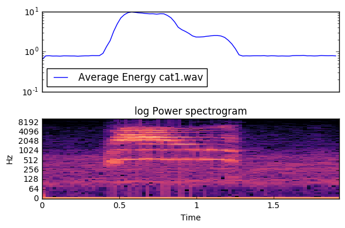

```python
cat1t, sr= librosa.load('dataTest/cat1.wav', duration=2.0) #load audio
cat1_test = librosa.feature.rmse(y=cat1t) #ekstraksi fitur
#plot
S = librosa.magphase(librosa.stft(cat1t, window=np.ones, center=False))[0]
rms = librosa.feature.rmse(S=S)
plt.figure()
plt.subplot(2, 1, 1)
plt.semilogy(rms.T, label='Average Energy cat1.wav')
plt.xticks([])
plt.xlim([0, rms.shape[-1]])
plt.legend(loc='best')
plt.subplot(2, 1, 2)
librosa.display.specshow(librosa.amplitude_to_db(S, ref=np.max), y_axis='log', x_axis='time')
plt.title('log Power spectrogram')
plt.tight_layout()
```

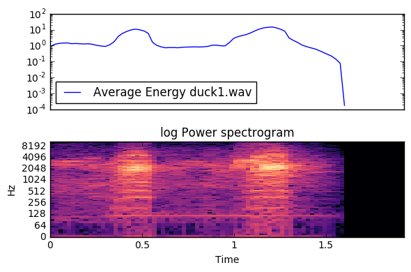

```python
duck1t, sr= librosa.load('dataTest/duck1.wav', duration=2.0) #load audio
duck1_test = librosa.feature.rmse(y=duck1t) #ekstraksi fitur
#plot
S = librosa.magphase(librosa.stft(duck1t, window=np.ones, center=False))[0]
rms = librosa.feature.rmse(S=S)
plt.figure()
plt.subplot(2, 1, 1)
plt.semilogy(rms.T, label='Average Energy duck1.wav')
plt.xticks([])
plt.xlim([0, rms.shape[-1]])
plt.legend(loc='best')
plt.subplot(2, 1, 2)
librosa.display.specshow(librosa.amplitude_to_db(S, ref=np.max), y_axis='log', x_axis='time')
plt.title('log Power spectrogram')
plt.tight_layout()
```

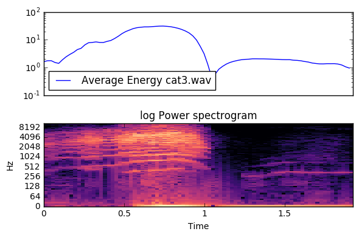

```python
cat3t, sr= librosa.load('dataTest/cat3.wav', duration=2.0) #load audio
cat3_test = librosa.feature.rmse(y=cat3t) #ekstraksi fitur
#plot
S = librosa.magphase(librosa.stft(cat3t, window=np.ones, center=False))[0]
rms = librosa.feature.rmse(S=S)
plt.figure()
plt.subplot(2, 1, 1)
plt.semilogy(rms.T, label='Average Energy cat3.wav')
plt.xticks([])
plt.xlim([0, rms.shape[-1]])
plt.legend(loc='best')
plt.subplot(2, 1, 2)
librosa.display.specshow(librosa.amplitude_to_db(S, ref=np.max), y_axis='log', x_axis='time')
plt.title('log Power spectrogram')
plt.tight_layout()
```

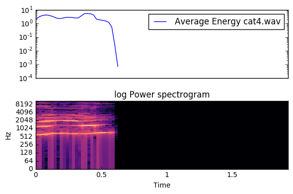

```python
cat4t, sr= librosa.load('dataTest/cat4.wav', duration=2.0) #load audio
cat4_test = librosa.feature.rmse(y=cat4t) #ekstraksi fitur
#plot
S = librosa.magphase(librosa.stft(cat4t, window=np.ones, center=False))[0]
rms = librosa.feature.rmse(S=S)
plt.figure()
plt.subplot(2, 1, 1)
plt.semilogy(rms.T, label='Average Energy cat4.wav')
plt.xticks([])
plt.xlim([0, rms.shape[-1]])
plt.legend(loc='best')
plt.subplot(2, 1, 2)
librosa.display.specshow(librosa.amplitude_to_db(S, ref=np.max), y_axis='log', x_axis='time')
plt.title('log Power spectrogram')
plt.tight_layout()
```

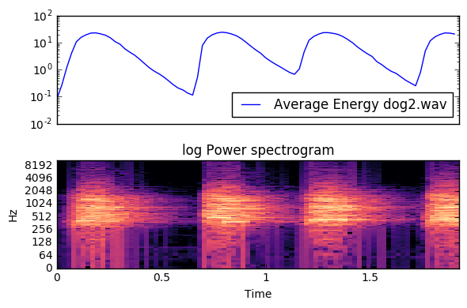

```python
dog2t, sr= librosa.load('dataTest/dog2.wav', duration=2.0) #load audio
dog2_test = librosa.feature.rmse(y=dog2t) #ekstraksi fitur
#plot
S = librosa.magphase(librosa.stft(dog2t, window=np.ones, center=False))[0]
rms = librosa.feature.rmse(S=S)
plt.figure()
plt.subplot(2, 1, 1)
plt.semilogy(rms.T, label='Average Energy dog2.wav')
plt.xticks([])
plt.xlim([0, rms.shape[-1]])
plt.legend(loc='best')
plt.subplot(2, 1, 2)
librosa.display.specshow(librosa.amplitude_to_db(S, ref=np.max), y_axis='log', x_axis='time')
plt.title('log Power spectrogram')
plt.tight_layout()
```

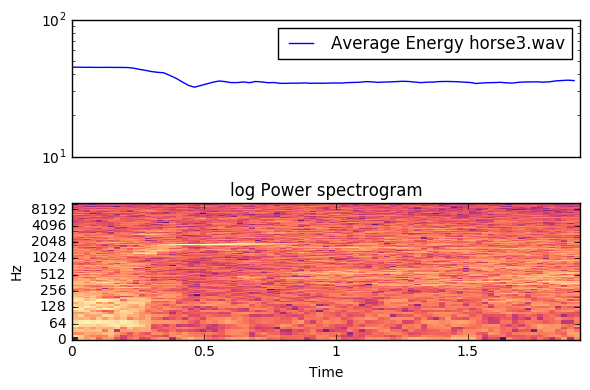

```python
horse3t, sr= librosa.load('dataTest/horse3.wav', duration=2.0) #load audio
horse3_test = librosa.feature.rmse(y=horse3t) #ekstraksi fitur
#plot
S = librosa.magphase(librosa.stft(horse3t, window=np.ones, center=False))[0]
rms = librosa.feature.rmse(S=S)
plt.figure()
plt.subplot(2, 1, 1)
plt.semilogy(rms.T, label='Average Energy horse3.wav')
plt.xticks([])
plt.xlim([0, rms.shape[-1]])
plt.legend(loc='best')
plt.subplot(2, 1, 2)
librosa.display.specshow(librosa.amplitude_to_db(S, ref=np.max), y_axis='log', x_axis='time')
plt.title('log Power spectrogram')
plt.tight_layout()
```

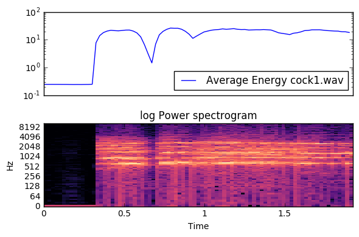

```python
cock1t, sr= librosa.load('dataTest/cock1.wav', duration=2.0) #load audio
cock1_test = librosa.feature.rmse(y=cock1t) #ekstraksi fitur
#plot
S = librosa.magphase(librosa.stft(cock1t, window=np.ones, center=False))[0]
rms = librosa.feature.rmse(S=S)
plt.figure()
plt.subplot(2, 1, 1)
plt.semilogy(rms.T, label='Average Energy cock1.wav')
plt.xticks([])
plt.xlim([0, rms.shape[-1]])
plt.legend(loc='best')
plt.subplot(2, 1, 2)
librosa.display.specshow(librosa.amplitude_to_db(S, ref=np.max), y_axis='log', x_axis='time')
plt.title('log Power spectrogram')
plt.tight_layout()
```

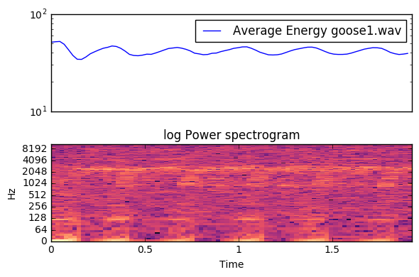

```python
goose1t, sr= librosa.load('dataTest/goose1.wav', duration=2.0) #load audio
goose1_test = librosa.feature.rmse(y=goose1t) #ekstraksi fitur
#plot
S = librosa.magphase(librosa.stft(goose1t, window=np.ones, center=False))[0]
rms = librosa.feature.rmse(S=S)
plt.figure()
plt.subplot(2, 1, 1)
plt.semilogy(rms.T, label='Average Energy goose1.wav')
plt.xticks([])
plt.xlim([0, rms.shape[-1]])
plt.legend(loc='best')
plt.subplot(2, 1, 2)
librosa.display.specshow(librosa.amplitude_to_db(S, ref=np.max), y_axis='log', x_axis='time')
plt.title('log Power spectrogram')
plt.tight_layout()
```

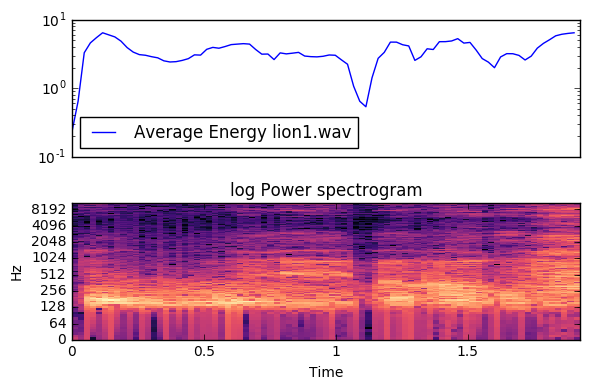

```python
lion1t, sr= librosa.load('dataTest/lion1.wav', duration=2.0) #load audio
lion1_test = librosa.feature.rmse(y=lion1t) #ekstraksi fitur
#plot
S = librosa.magphase(librosa.stft(lion1t, window=np.ones, center=False))[0]
rms = librosa.feature.rmse(S=S)
plt.figure()
plt.subplot(2, 1, 1)
plt.semilogy(rms.T, label='Average Energy lion1.wav')
plt.xticks([])
plt.xlim([0, rms.shape[-1]])
plt.legend(loc='best')
plt.subplot(2, 1, 2)
librosa.display.specshow(librosa.amplitude_to_db(S, ref=np.max), y_axis='log', x_axis='time')
plt.title('log Power spectrogram')
plt.tight_layout()
```

### Pengenalan Kemiripan

Pengenalan kemiripan disini dilakukan oleh MLPClassifier() yang akan mengklasifikasikan ke data yang paling mirip. Karena kita menggunakan average energy saja maka MLPClassifier mengklasifikasikan data yang average energy nya paling mirip.

```python
data_test = [cat1_test.ravel(), duck1_test.ravel(), cat3_test.ravel(), cat4_test.ravel(), dog2_test.ravel(), horse3_test.ravel(), cock1_test.ravel(), goose1_test.ravel(), lion1_test.ravel()]
pred = mlp.predict(data_test)
```

### Hasil

```python
print(pred)
```

```
['cat' 'duck' 'horse' 'cat' 'dog' 'horse' 'duck' 'horse' 'cat']
```

Secara urut dari hasil prediksi tersebut :

Data dari database

1 cat1.wav --> cat, benar

2 duck1.wav --> duck, benar

Data dari luar database

3 cat3.wav --> horse, salah

4 cat4.wav --> cat, benar

5 dog2.wav --> dog, benar

6 horse3.wav --> horse, benar

Data yang tidak ada labelnya di database

7 cock1.wav --> duck, n/a

8 goose1.wav --> horse, n/a

9 lion1.wav --> cat, n/a

Dari hasil tersebut 5/6 data yang ada labelnya di database benar. Hanya cat3.wav yang salah, dikenali sebagai horse. Setelah di cek average energynya di grafik cat3.wav memiliki kesamaan pola dengan horse1.wav dimana energynya berada di kisaran 10^0-10^1.

Untuk data yang tidak ada di database, MLPClassifier() tetap mencari data tersebut paling mirip dengan apa. Untuk cock1.wav yang diprediksi sebagai duck dan lion1.wav yang diprediksi sebagai cat, klasifikasi berdasarkan average energy berjalan cukup baik mengingat cock-duck dan lion-cat masih satu family yang sama.

goose1.wav diprediksi sebagai suara horse. Terdengar tidak berkaitan, tetapi pada average energy goose1.wav dengan horse2.wav grafiknya mirip dengan energy di kisaran 10^1-10^2 dan relatif datar.

Dari sini dapat disimpulkan mengenali suara hanya dari average energynya sudah cukup akurat, namun masih terdapat error. Untuk mengatasi error dapat dilakukan dengan menambah fitur untuk di train, menambah data test karena semakin banyak data untuk train maka semakin akurat, dan melakukan enhancement seperti normalisasi atau noise removal pada data test maupun data train.